# A3: Incarceration

### Variable Comparison Chart: Change in Black Incarcerations over time

This chart helps us focus on the change in the number of incarcerations of Black people. As we can see, the percent of Black incarcerations started to decline in 2008-2009. A similar trend can be observed in the chart above. During my analysis, I was curious as to what exactly caused the decline. Any guesses? In 2008, Barack Obama was elected as the 44th President of the United States. Mr. Obama’s election could be one of the biggest drivers behind Black incarcerations falling.

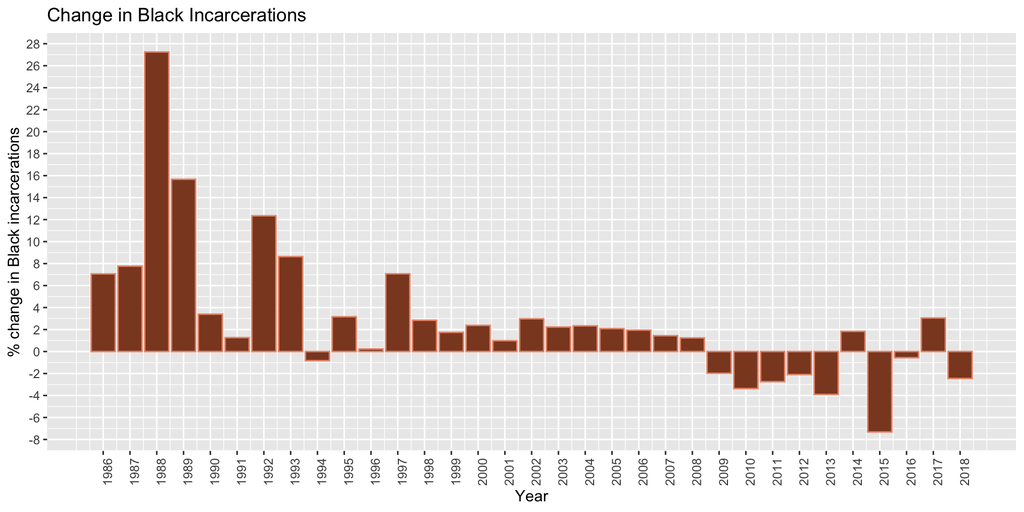

### Map: Incarcerations in the U.S. in 2018 by state

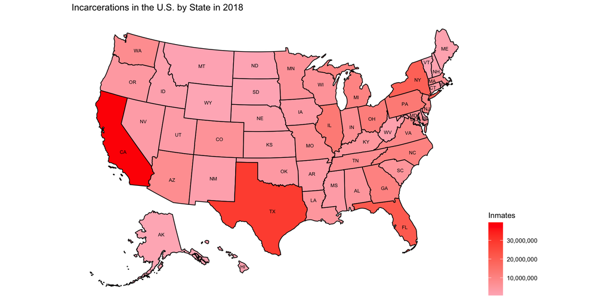